# Logit model and Poisson model

Nhat My Thien Nguyen

4/15/2021

```r
knitr::opts_chunk$set(echo = TRUE)

library(tidyverse)
library(kableExtra)
library(readr)
library(readxl)
library(lmtest)
library(stargazer)
library(car)
library(broom)
library(ivreg)
library(systemfit)
library(mfx)
library(AER)
```

# Problem 3

1. Develop a logistic regression model to predict the probability that a customer purchases the organic products, based on age and whether the customer subscribes to the supermarket chain’s health/wellness e‐newsletters. Interpret the PEA and APE measures of marginal effects for the two explanatory variables.

```r
organic<-read_excel("OrganicDecision.xlsx")
organic<-rename(organic,"Purchaser"="Organic Food Purchaser","Subscriber"="Online Health Wellness e-Newsletters Subscriber")
organic
```

```
## # A tibble: 100 x 3
##    Purchaser   Age Subscriber
##        <dbl> <dbl>      <dbl>
##  1         1    26          0
##  2         1    25          1
##  3         1    27          0
##  4         1    27          0
##  5         1    27          0
##  6         1    27          1
##  7         1    28          1
##  8         1    28          1
##  9         1    30          1
## 10         1    31          1
## # ... with 90 more rows
```

```r
correlation.matrix<-cor(organic)
kable(correlation.matrix)
```

|  | Purchaser | Age | Subscriber |
| --- | --- | --- | --- |
| Purchaser | 1.0000000 | -0.1979227 | 0.3407364 |
| Age | -0.1979227 | 1.0000000 | -0.0496893 |
| Subscriber | 0.3407364 | -0.0496893 | 1.0000000 |

```r
organic_glm<-glm(Purchaser~Age+Subscriber,family=binomial(link="logit"),data=organic)
summary(organic_glm)
```

```
##
## Call:
## glm(formula = Purchaser ~ Age + Subscriber, family = binomial(link = "logit"),
##     data = organic)
##
## Deviance Residuals:
##     Min       1Q   Median       3Q      Max
## -2.0402  -1.1021   0.5243   0.8897   1.5036
##
## Coefficients:
##             Estimate Std. Error z value Pr(>|z|)
## (Intercept)  1.60048    0.88201   1.815  0.06959 .
## Age         -0.03251    0.01698  -1.915  0.05546 .
## Subscriber   1.58299    0.48579   3.259  0.00112 **
## ---
## Signif. codes:  0 '***' 0.001 '**' 0.01 '*' 0.05 '.' 0.1 ' ' 1
##
## (Dispersion parameter for binomial family taken to be 1)
##
##     Null deviance: 129.49  on 99  degrees of freedom
## Residual deviance: 113.53  on 97  degrees of freedom
## AIC: 119.53
##
## Number of Fisher Scoring iterations: 4
```

### At the Mean X (PEA: Partial Effect at the Average)

```r
logitmfx(Purchaser~Age+Subscriber,data=organic,atmean=TRUE)
```

```
## Call:
## logitmfx(formula = Purchaser ~ Age + Subscriber, data = organic,
##     atmean = TRUE)
##
## Marginal Effects:
##                 dF/dx  Std. Err.       z    P>|z|
## Age        -0.0070844  0.0036600 -1.9356 0.052915 .
## Subscriber  0.3272235  0.0888872  3.6813 0.000232 ***
## ---
## Signif. codes:  0 '***' 0.001 '**' 0.01 '*' 0.05 '.' 0.1 ' ' 1
##
## dF/dx is for discrete change for the following variables:
##
## [1] "Subscriber"
```

This result of PEA marginal effect shows that when age increase by 1 year old from its average value, the probability of purchasing organic products decrease 0.7%. And when a person subscribing to Online Health Wellness e-Newsletters will have probability of buying organic product increase 32.7%.

### Mean Partial Effect for all X (APE: Average Partial Effect)

```r
logitmfx(Purchaser~Age+Subscriber,data=organic,atmean=FALSE)
```

```
## Call:
## logitmfx(formula = Purchaser ~ Age + Subscriber, data = organic,
##     atmean = FALSE)
##
## Marginal Effects:
##                 dF/dx  Std. Err.       z     P>|z|
## Age        -0.0062776  0.0035709 -1.7580 0.0787454 .
## Subscriber  0.3183215  0.0867267  3.6704 0.0002422 ***
## ---
## Signif. codes:  0 '***' 0.001 '**' 0.01 '*' 0.05 '.' 0.1 ' ' 1
##
## dF/dx is for discrete change for the following variables:
##
## [1] "Subscriber"
```

This result of APE marginal effect shows that when age increase by 1 year old, the probability of purchasing organic products decrease 0.6%. And a person subscribing to Online Health Wellness e-Newsletters will have probability of buying organic product increase 31.8%.

2. At the 0.05 level of significance, is there evidence that a logistic regression model that uses customer age and whether the customer subscribes to the supermarket chain’s health/wellness e‐newsletters to predict the probability of purchasing the organic products is a good fitting model?

–> We use lrtest to test model

```r
lrtest(organic_glm)
```

```
## Likelihood ratio test
##
## Model 1: Purchaser ~ Age + Subscriber
## Model 2: Purchaser ~ 1
##   #Df  LogLik Df  Chisq Pr(>Chisq)
## 1   3 -56.766
## 2   1 -64.745 -2 15.956  0.0003429 ***
## ---
## Signif. codes:  0 '***' 0.001 '**' 0.01 '*' 0.05 '.' 0.1 ' ' 1
```

Since p-value is <0.05, so we can conclude at 0.05 level of significance, a logistic regression model that uses customer age and whether the customer subscribes to the supermarket chain’s health/wellness e‐newsletters to predict the probability of purchasing the organic products is a good fitting model.

3. At the 0.05 level of significance, is there evidence that customer age and whether the customer subscribes to the supermarket chain’s health/wellness e‐newsletters each make a significant contribution to the logistic model?

```r
stargazer(organic_glm,type='text')
```

```
##
## =============================================
##                       Dependent variable:
##                   ---------------------------
##                            Purchaser
## ---------------------------------------------
## Age                         -0.033*
##                             (0.017)
##
## Subscriber                 1.583***
##                             (0.486)
##
## Constant                    1.600*
##                             (0.882)
##
## ---------------------------------------------
## Observations                  100
## Log Likelihood              -56.766
## Akaike Inf. Crit.           119.533
## =============================================
## Note:             *p<0.1; **p<0.05; ***p<0.01
```

The p-value of Subscriber is 0.001, which means at the 0.05 level of significance, the customer subscribes to the supermarket chain’s health/wellness e‐newsletters each make a significant contribution to the logistic model.

The p-value of Age is 0.055, which means at the 0.05 level of significance, the customer’s age does not make a significant contribution to the logistic model.

4. Create a confusion matrix to check the accuracy of your model.

```r
table<-data.frame(table(true=organic$Purchaser,
              predicted=round(fitted(organic_glm))))
kable(table, align='c', caption="Logit Confusion Matrix")
```

Logit Confusion Matrix

| true | predicted | Freq |
| --- | --- | --- |
| 0 | 0 | 16 |
| 1 | 0 | 14 |
| 0 | 1 | 19 |
| 1 | 1 | 51 |

Logit confusion matrix

# Problem 4

```r
awards<-read_excel("Awards.xlsx")
```

```
## * `` -> ...1
```

```r
awards_dummy<- fastDummies::dummy_cols(awards,select_columns='prog')
```

1. First estimate a linear regression model using OLS and check if the assumptions of OLS regression hold.

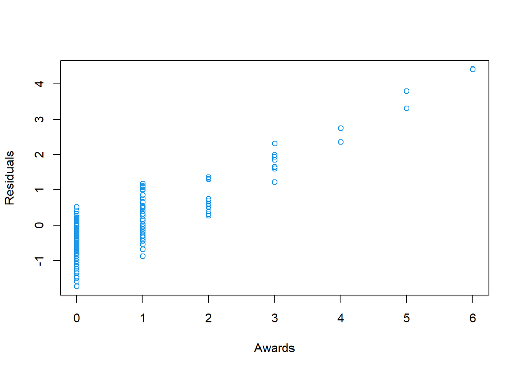

```r
awards.OLS <-lm(num_awards~math+prog_Arts+prog_Business,data=awards_dummy)
ehat<-awards.OLS$residuals
plot(awards_dummy$num_awards,ehat,xlab="Awards",ylab="Residuals",col=4)
```

–> Equal variance (homosdascity) is violated.

2. Estimate a Poisson model using the glm function with the poisson specification.

```r
poisson1<-glm(num_awards~math+prog_Arts+prog_Business,family="poisson",na.action=na.omit,data=awards_dummy)
kable(tidy(poisson1),digits=4,caption="Poisson model 1")
```

Poisson model 1

| term | estimate | std.error | statistic | p.value |
| --- | --- | --- | --- | --- |
| (Intercept) | -4.1633 | 0.6629 | -6.2806 | 0.0000 |
| math | 0.0702 | 0.0106 | 6.6186 | 0.0000 |
| prog_Arts | -0.7140 | 0.3200 | -2.2313 | 0.0257 |
| prog_Business | -1.0839 | 0.3583 | -3.0254 | 0.0025 |

```r
dispersiontest(poisson1)
```

```
##
##  Overdispersion test
##
## data:  poisson1
## z = 0.53224, p-value = 0.2973
## alternative hypothesis: true dispersion is greater than 1
## sample estimates:
## dispersion
##   1.047254
```

3. Estimate a Poisson using a quasipoisson model using the glm function with the quasipoisson specification.

```r
poisson2<-glm(num_awards~math+prog_Arts+prog_Business,family="quasipoisson",na.action=na.omit,data=awards_dummy)
kable(tidy(poisson2),digits=4, align='c',caption="Poisson model 2")
```

Poisson model 2

| term | estimate | std.error | statistic | p.value |
| --- | --- | --- | --- | --- |
| (Intercept) | -4.1633 | 0.6896 | -6.0369 | 0.0000 |
| math | 0.0702 | 0.0110 | 6.3618 | 0.0000 |
| prog_Arts | -0.7140 | 0.3329 | -2.1447 | 0.0332 |
| prog_Business | -1.0839 | 0.3727 | -2.9080 | 0.0041 |

4. Compare the results from parts a, b and c. Are there any differMaences? If yes, why?

```r
stargazer(awards.OLS,poisson1,poisson2,type="text",keep.stat="n",intercept.bottom=FALSE)
```

```
##
## ===================================================
##                        Dependent variable:
##               -------------------------------------
##                            num_awards
##                  OLS     Poisson  glm: quasipoisson
##                                      link = log
##                  (1)       (2)           (3)
## ---------------------------------------------------
## Constant      -1.717*** -4.163***     -4.163***
##                (0.450)   (0.663)       (0.690)
##
## math          0.048***  0.070***      0.070***
##                (0.008)   (0.011)       (0.011)
##
## prog_Arts      -0.266   -0.714**      -0.714**
##                (0.174)   (0.320)       (0.333)
##
## prog_Business -0.479*** -1.084***     -1.084***
##                (0.169)   (0.358)       (0.373)
##
## ---------------------------------------------------
## Observations     200       200           200
## ===================================================
## Note:                   *p<0.1; **p<0.05; ***p<0.01
```